# Análise exploratória de mortes por psicoativos no ES

Iane Martins

20/06/2024

## 1. Introdução

Este relatório busca examinar as variáveis sociodemográficas presentes na base de dados do Sistema de Informação sobre Mortalidade (SIM) em relação às mortes por psicoativos ocorridas no estado do Espírito Santo entre os anos de 2018 e 2022. Para obter os dados desse tipo específico de morte, foram usados os Códigos Diagnósticos (CID) de F10 até F19.

As variáveis sociodemográficas selecionadas foram: **Idade**, **Gênero**, **Raça**, **Escolaridade** e **Estado Civil**. Aspectos como a quantidade de **Mortes por Ano** também foram incluídos no relatório para um melhor entendimento dos dados.

## 2. Mortes por ano

Para começar a análise, é importante ter uma ideia geral dos dados que estão sendo analisados. Nos gráficos a seguir, é possível observar o número de óbitos totais e o número de óbitos por psicoativos no estado do Espírito Santo entre os anos de 2018 e 2022. Nos óbitos totais estão incluídos todos os tipos de óbitos registrados e nos óbitos por psicoativos estão incluídos todos aqueles cuja causa básica da morte foi definida por um CID de F10 a F19.

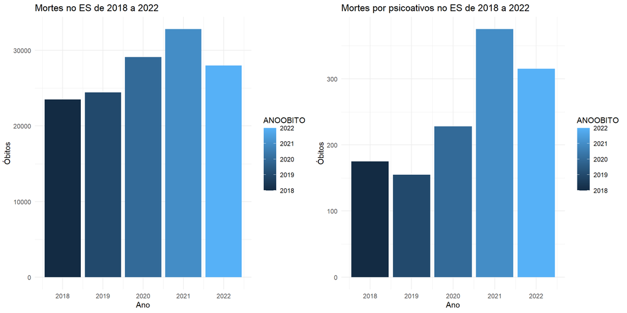

É possível perceber que em ambos os gráficos o número de óbitos tem um aumento no ano de 2020, alcança seu ponto máximo no ano de 2021 e decresce no ano de 2022. Entretanto, ao observar a inclinação dessa curva de crescimento é notório, em termos proporcionais, que o número de mortes por psicoativos cresceu mais do que os óbitos totais. A tabela abaixo apresenta números mais precisos sobre essa relação.

| Ano | Mortes Totais | % MT | Mortes por Psicoativos | % MP | MP/1000 MT |
| --- | --- | --- | --- | --- | --- |
| 2018 | 23500 | 17.04937 | 175 | 14.02244 | 7.446809 |
| 2019 | 24431 | 17.72482 | 155 | 12.41987 | 6.344398 |
| 2020 | 29111 | 21.12018 | 228 | 18.26923 | 7.832091 |
| 2021 | 32801 | 23.79729 | 375 | 30.04808 | 11.432578 |
| 2022 | 27992 | 20.30834 | 315 | 25.24038 | 11.253215 |

Além disso, a tabela também mostra o número de óbitos por psicoativos a cada 1000 mortes totais. Em 2018, 2019 e 2020, a cada 1000 pessoas falecidas, de 6 a 8 faleceram por uso de psicoativos. Em 2021 e 2022, esse número aumentou para aproximadamente 11 pessoas a cada 1000.

## 3. Gênero

A primeira variável sociodemográfica analisada neste relatório é o gênero. Nos óbitos totais, os homens representam aproximadamente 56,42% das ocorrências, enquanto as mulheres compõem cerca de 43,50%. Já nas mortes por psicoativos, a proporção é de 85,74% para os homens contra 14,26% para as mulheres. Ao observar o número de mortes totais por gênero e o número de mortes por psicoativos também relacionados ao gênero, tem-se que a cada 1000 mulheres falecidas aproximadamente 3 morrem por uso de psicoativos; em contraste, a cada 1000 homens mortos aproximadamente 14 vão a óbito devido ao uso de psicoativos.

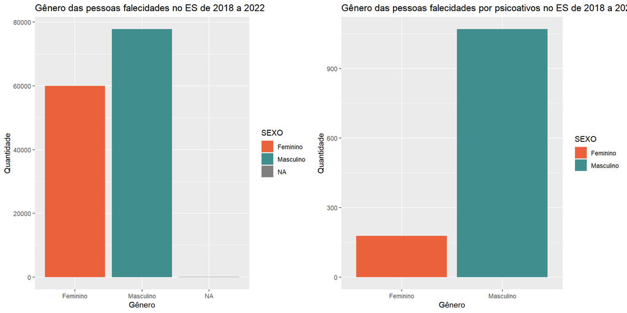

| Genero | Mortes Totais | % MT | Mortes por Psicoativos | % MP | MP/1000 MT |
| --- | --- | --- | --- | --- | --- |
| Feminino | 59963 | 43.50346 | 178 | 14.26282 | 2.968497 |
| Masculino | 77773 | 56.42471 | 1070 | 85.73718 | 13.757988 |

## 4. Idade

Para facilitar a análise dos dados relativos à idade dos falecidos, optou-se por utilizar faixas etárias, dividindo os indivíduos em cinco grupos:

1. Crianças **(inf-12]**;
2. Adolescentes **(13-17]**;
3. Jovens adultos **(18-30]**;
4. Adultos **(31-60]**;
5. Idosos **(61-inf]**.

Ao observar os gráficos, nota-se uma discrepância significativa nas idades predominantes entre os falecidos. Nos óbitos totais, o grupo dos idosos (mais de 60 anos) apresenta o maior número de óbitos. Em contraste, no grupo de óbitos por psicoativos, é o grupo dos adultos (31-60 anos) que registra o maior número de mortes.

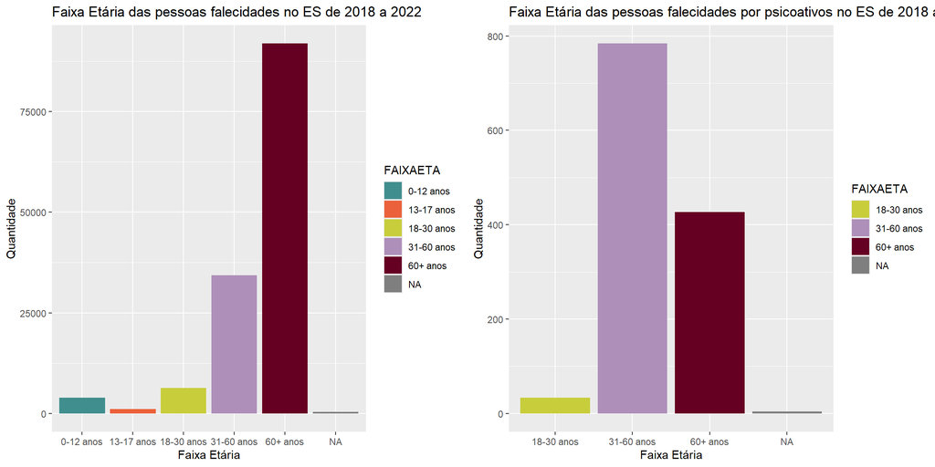

Fazendo o cálculo da média de idade de falecimento do grupo de óbitos totais e do grupo de óbitos por psicoativos, tem-se que a média do primeiro grupo foi de aproximadamente 65,5806 anos, enquanto a do segundo foi de aproximadamente 55,4799 anos. Isso resulta em uma diferença de aproximadamente 10 anos na idade média de morte desses dois grupos.

Em relação à mediana, tem-se que a mediana de idade de falecimento do grupo de óbitos totais foi de 69 anos, enquanto no grupo de óbitos por psicoativos foi de aproximadamente 55 anos. Uma diferença de 14 anos.

## 5. Raça, Escolaridade e Estado Civil

No que diz respeito à **raça** dos falecidos, tem-se que, nos óbitos totais, a maior parte das pessoas se considerava branca, seguida de pessoas pardas e, posteriormente, pretas. No grupo de óbitos por psicoativos, a maior parte das pessoas se considerava parda, seguida de brancas e, por último, pretas.

O número de pessoas declaradas amarelas e indígenas se mostrou bastante baixo quando comparado às outras três raças e não mudou de proporção entre os dois grupos analisados neste relatório.

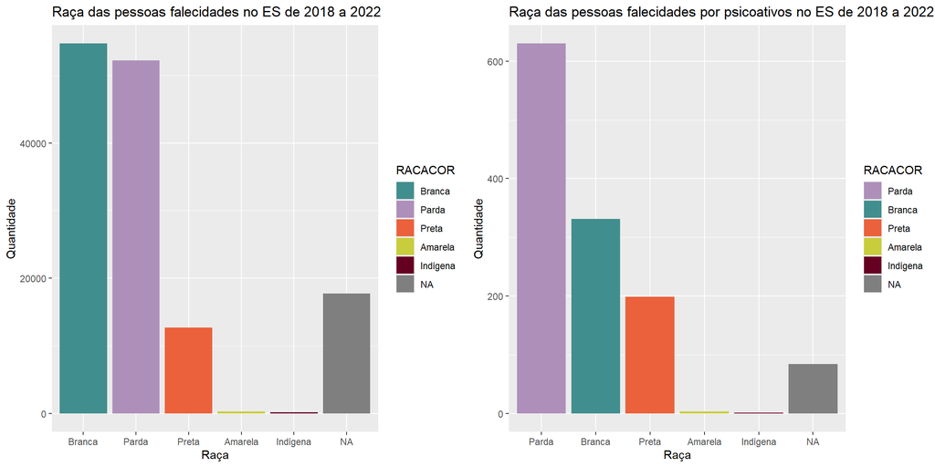

Sobre a variável **escolaridade**, os dados mostraram uma presença considerável de dados NA, ou seja, que não possuem nenhum valor atribuído, o que pode alterar o nosso entendimento em relação às informações apresentadas por essa variável. Além disso, quando observados os anos de escolaridade, tem-se que o grupo de 1 a 3 anos de escolaridade é o com maior valor atribuído nos óbitos totais, enquanto nas mortes por psicoativos é o grupo de 4 a 7 anos de escolaridade.

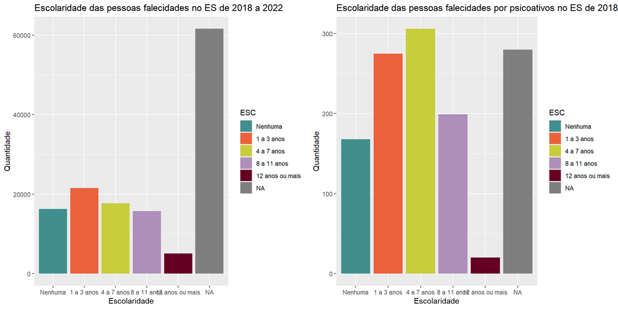

Ao analisar os dados de **estado civil**, percebe-se que, enquanto a maior parte dos falecidos totais é casada, quando se observa os falecidos por psicoativos, a maior parte deles é solteira. Isso pode ser um bom indicativo caso haja interesse em mostrar o perfil de pessoa mais propensa a morrer por uso de psicoativos.

Vale ressaltar que o número de dados não atribuídos (NA) nessa variável também foi considerável.

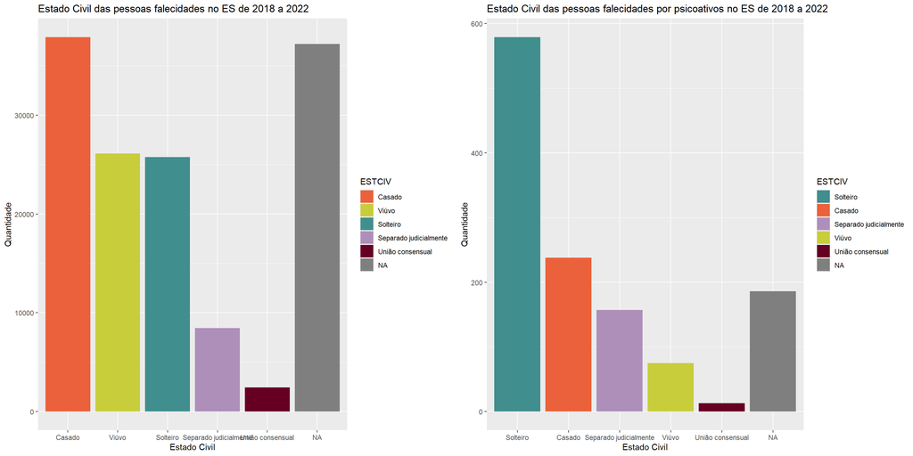

## 6. Observações

1. Os dados NA não foram removidos devido à sua grande quantidade de ocorrência em algumas variáveis. Entendeu-se necessário conversar com toda a equipe para decidir qual seria a melhor maneira de trabalhar com eles.
2. Na análise de faixa etária, optou-se por plotar o gráfico com grupos de tamanhos diferentes para evidenciar de fato o consumo de psicoativos por faixa etária. No entanto, é viável conversar com a equipe para verificar se esse tipo de agrupamento é apropriado.